# Sub Studi Analitik Spatiotemporal Dengue di Kab. Sleman

Author

Moch. Thoriq Assegaf Al-Ayubi

Modified

April 29, 2026

# Temporal

## Tren Dengue di Kab. Sleman

Tren kasus dengue di Kabupaten Sleman tahun 2016-2025 adalah sebagai berikut:

[interactive chart not shown]

## Tren Incidence Rate Dengue di Kab. Sleman

Adapun trend insidence rate Dengue di Kabupaten Sleman tahun 2016-2025 adalah sebagai berikut:

[interactive chart not shown]

Adapun versi detailnya adalah sebagai berikut:

### Demam Berdarah Dengue

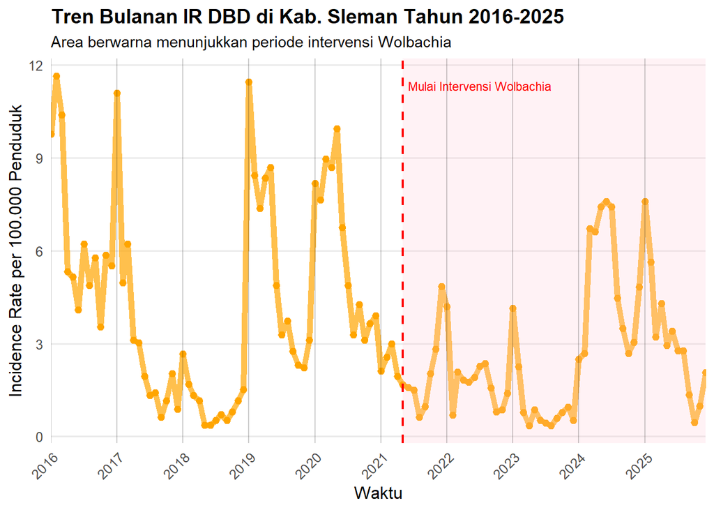

### Demam Dengue

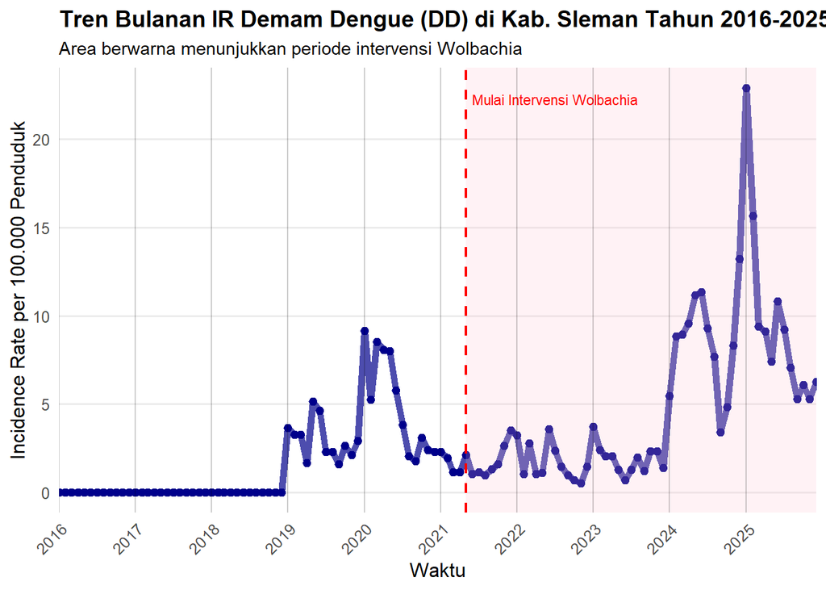

### Infeksi Dengue

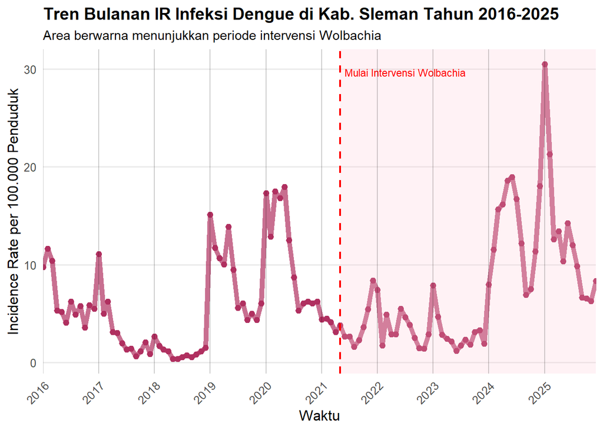

## Trend Komparasi Wilayah Wolbachia VS non-Wolbachia

Perbandingan tren incidence rate antara wilayah wolbachia dengan wilayah non wolbachia di Kab. Sleman adalah sebagai berikut:

[interactive chart not shown]

Adapun versi detailnya adalah sebagai berikut:

### Demam Berdarah Dengue

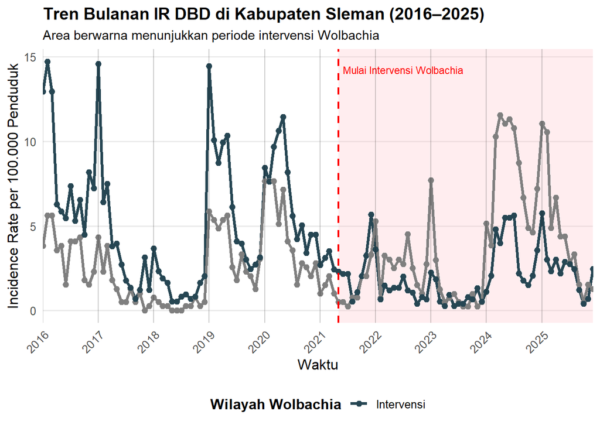

### Demam Dengue

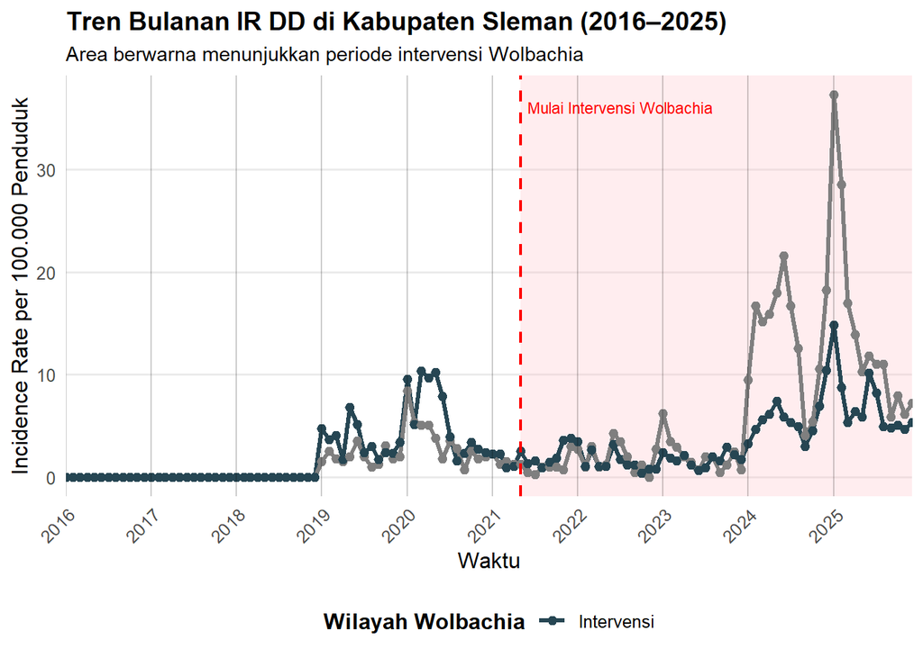

### Infeksi Dengue

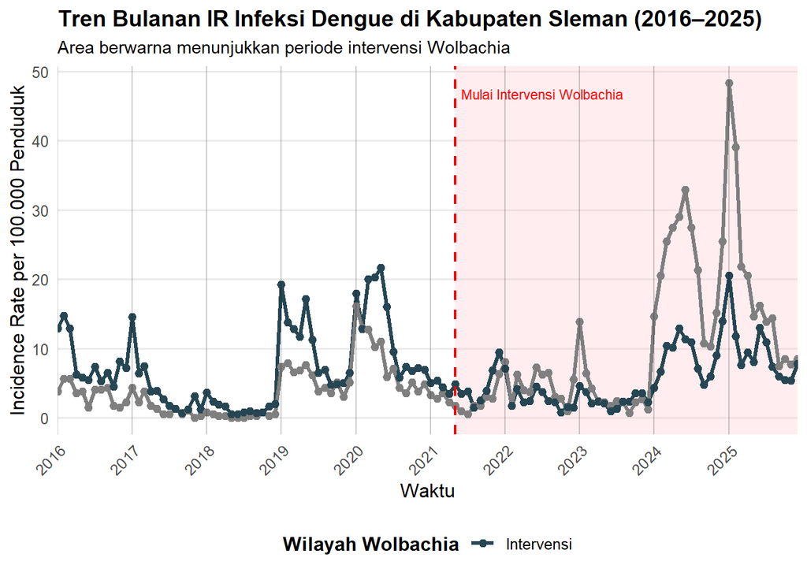

## Heatmap Trend IR Dengue per Desa

### Demam Berdarah Dengue

[interactive chart not shown]

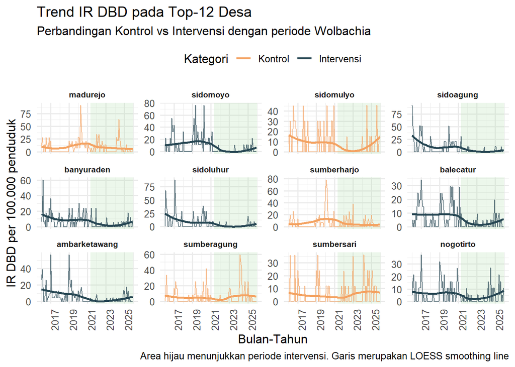

### Demam Dengue

[interactive chart not shown]

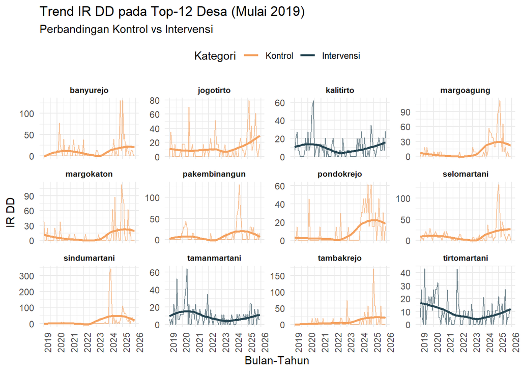

### Infeksi Dengue

[interactive chart not shown]

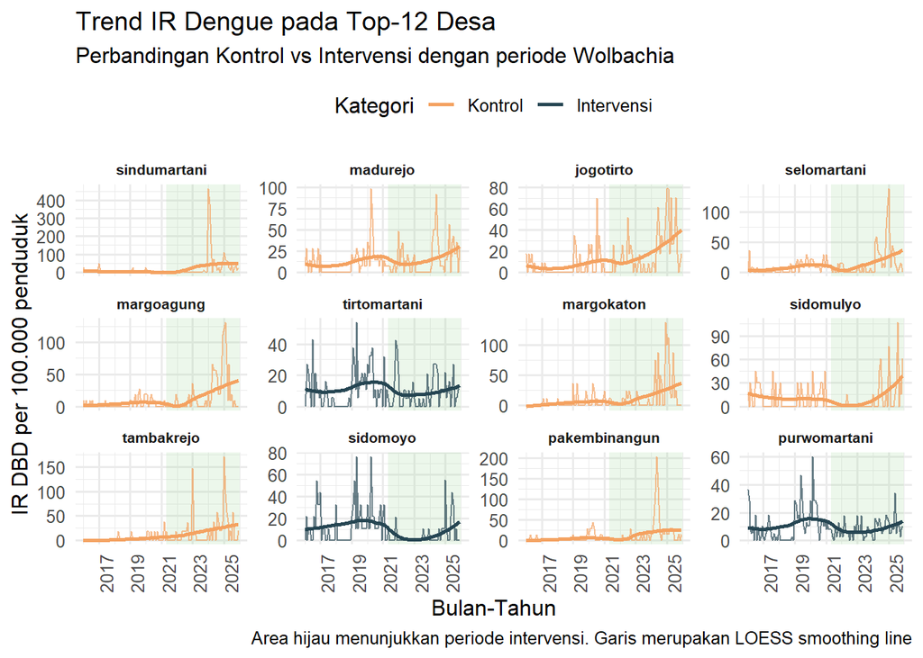

## Trend Prediktor: ABJ

Adapun trend Angka Bebas Jentik (ABJ) secara Kabupaten adalah sebagai berikut:

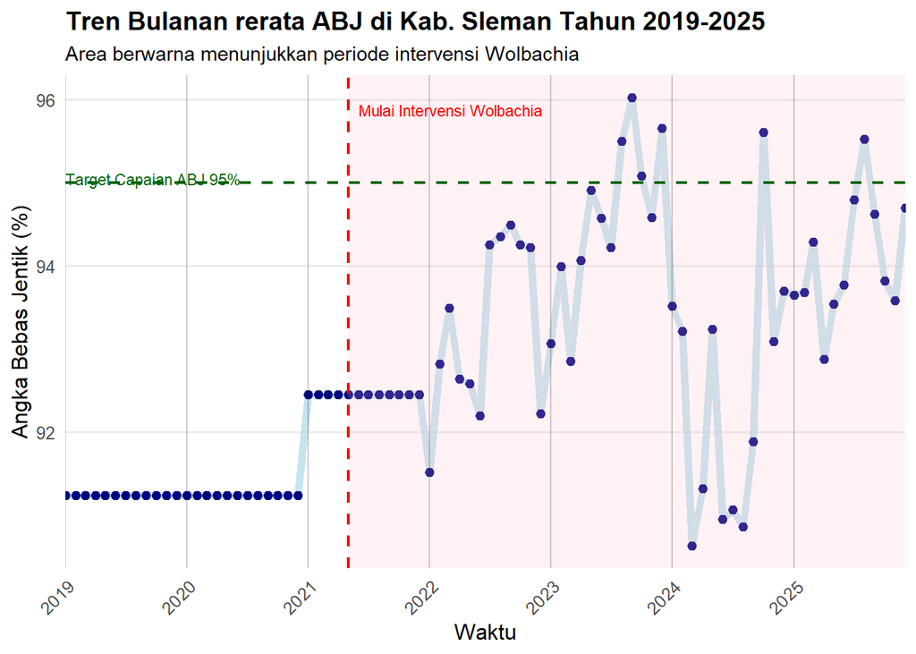

Adapun berdasarkan wilayah intervensi adalah sebagai berikut:

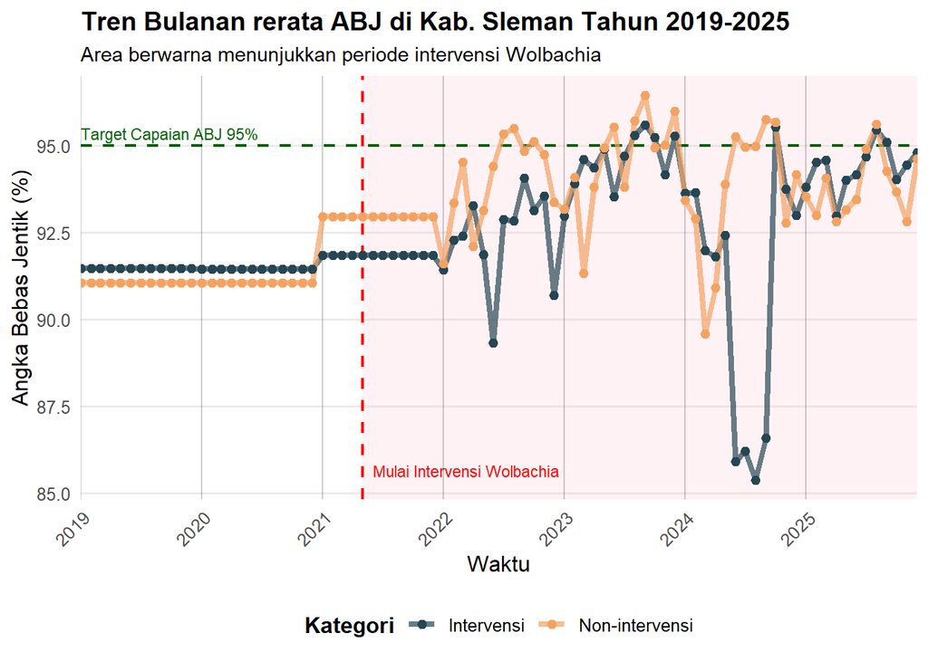

## Trend Prediktor: Kegiatan Fogging

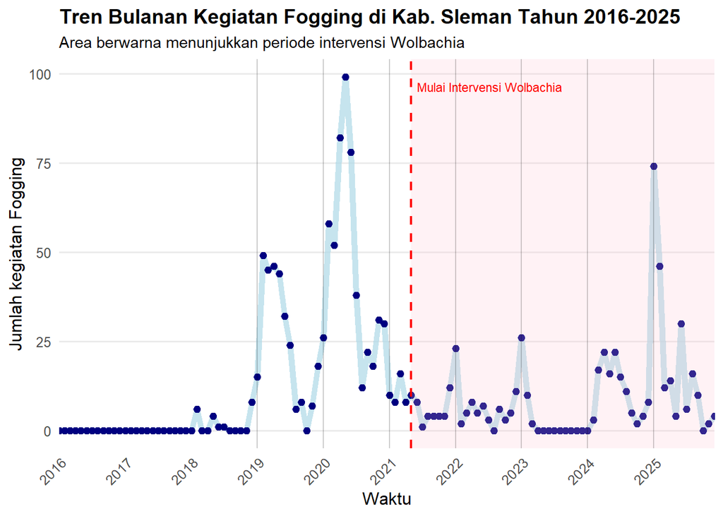

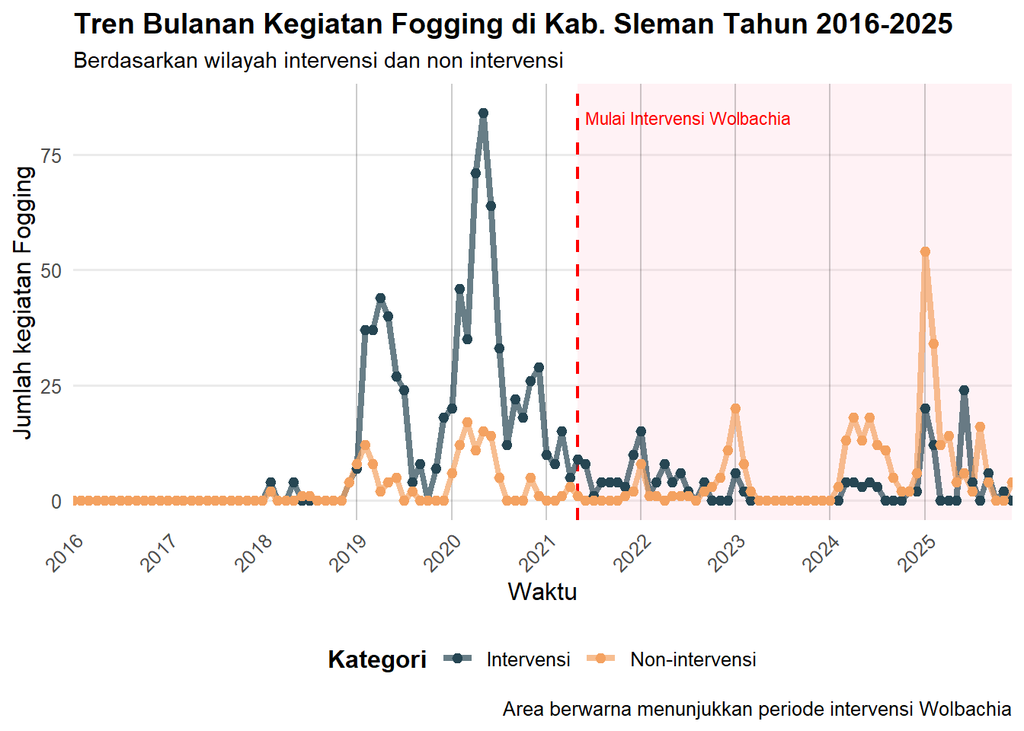

## Trend Prediktor: Covid-19

Adapun trend kasus covid-19 di Kab. Sleman adalah sebagai berikut:

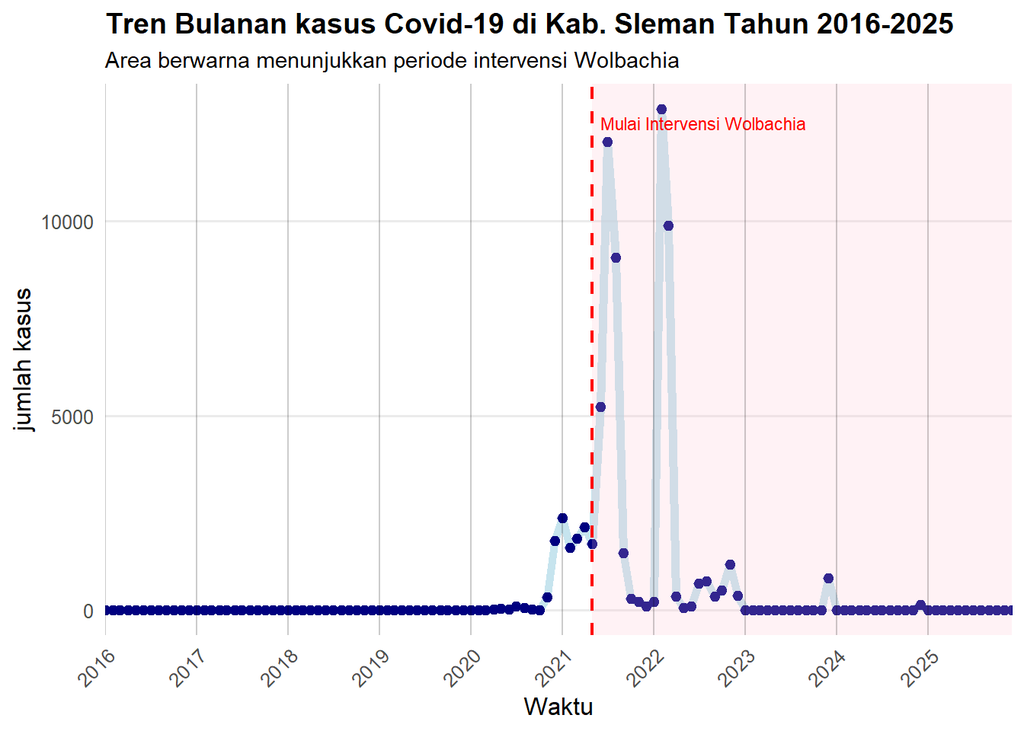

## Kepadatan Penduduk

Komparasi Kepadatan Penduduk

| Area | Luas Wilayah (km2) | Total Populasi | Kepadatan Penduduk/km2 | Penduduk usia <16 tahun (%) |
| --- | --- | --- | --- | --- |
| Kontrol | 324 | 389.145 | 1.200 | 20,46 |
| Intervensi | 251 | 729.208 | 2.895 | 21,16 |
| Total | 575 | 1.118.353 | 1.942 | 20,92 |

# Spatial

Hasil analisis deskriptif disajikan sebagaimana berikut:

| Variabel | mean | SD | median | min | max |
| --- | --- | --- | --- | --- | --- |
| Lahan Pemukiman (%) | 25.86 | 10.40 | 26.09 | 5.27 | 63.69 |
| Kepadatan Penduduk | 2,129.66 | 1,294.60 | 1,857.50 | 377.00 | 8,137.00 |
| Rumah Diperiksa (%) | 218.71 | 266.60 | 109.61 | 2.83 | 1,357.32 |
| DSI | 11.36 | 1.41 | 12.00 | 8.00 | 15.00 |
| ABJ (%) | 93.46 | 4.34 | 94.54 | 75.59 | 100.00 |
| Rerata Ketinggian (mdpl) | 248.88 | 195.06 | 182.56 | 80.64 | 1,158.32 |
| Skor Kapasitas | 64.16 | 5.57 | 64.56 | 52.28 | 73.26 |
| Indeks Dukungan | 44.59 | 18.19 | 39.30 | 10.30 | 93.00 |
| IR Dengue 2025 | 175.39 | 119.87 | 125.97 | 16.00 | 573.27 |

adapun hasil uji beda dua mean disajikan dalam tabel berikut:

Uji Beda Status Wolbachia

[output not shown]

## Incidence Rate Dengue

Hasil uji global moran’s I disajikan sebagai berikut

Global Moran’s I Analysis

| Indicator | Value |
| --- | --- |
| Moran’s I | 0.307 |
| Expected Index | -0.012 |
| Variance | 0.004 |
| Z-score | 4.835 |
| P-value | 0.000 |

Berdasarkan tabel, diketahui bahwa analisis Global Moran’s I menunjukkan autokorelasi spatial yang signifikan positif dengan clustering tendency sedang (Moran’s I = 0.307; z-score = 4.835; p-value = 6.65e-07).

Adapun peta distribusi spatial ditunjukkan pada gambar dibawah ini.

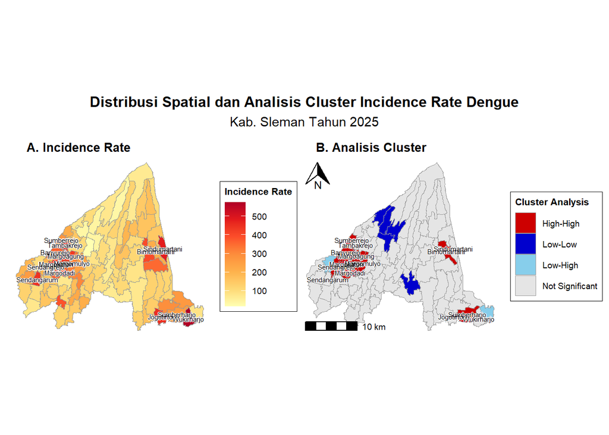

## Dimensi Kapasitas

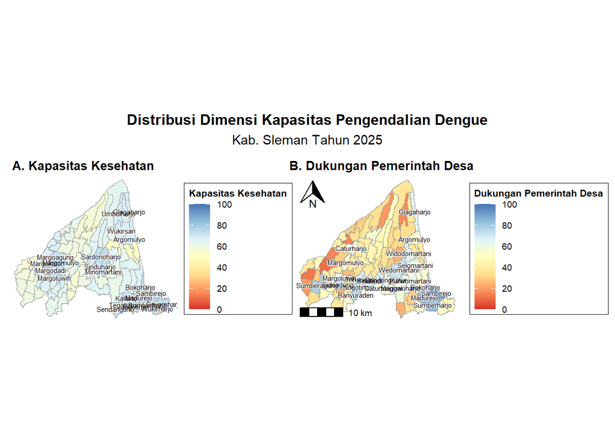

## Dimensi Kerentanan

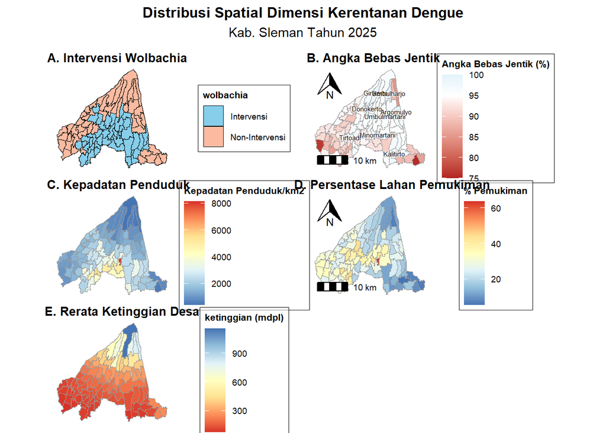

## Dimensi Keparahan

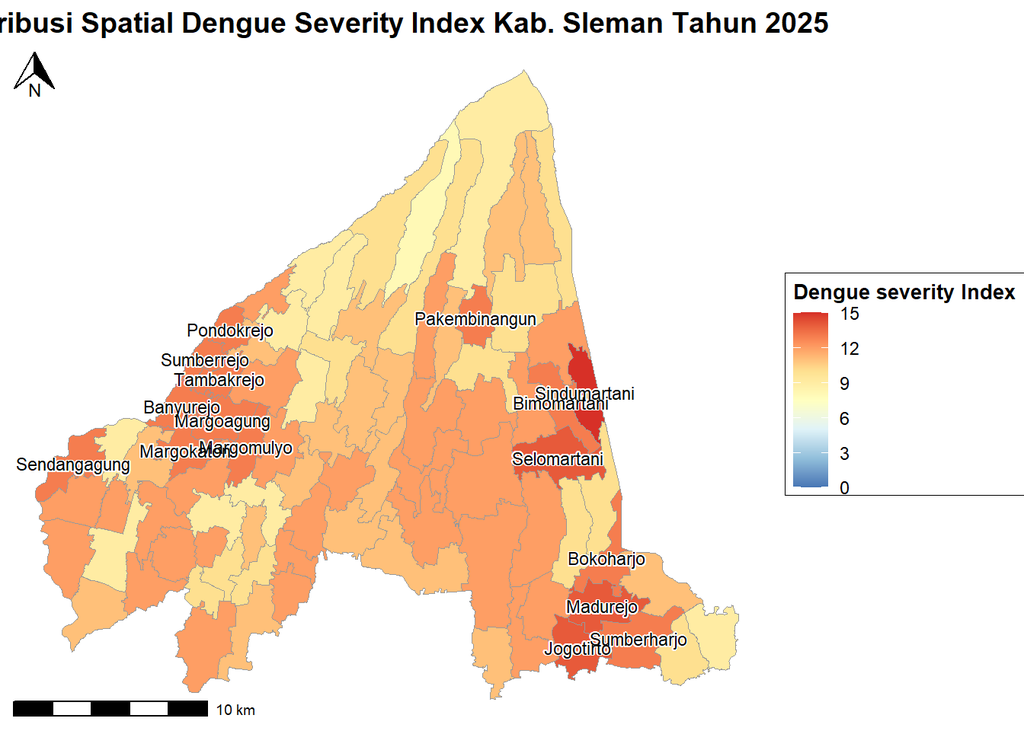